# Project4_3011_chaoz3

zhuchao

13/12/2020

```r
library(recommenderlab)
library(Matrix)
library(dplyr)
```

```r
library(ggplot2)
library(DT)
library(data.table)
library(reshape2)
```

Load ratings data

```r
myurl = "https://liangfgithub.github.io/MovieData/"
ratings = read.csv(paste0(myurl, 'ratings.dat?raw=true'),
                   sep = ':',
                   colClasses = c('integer', 'NULL'),
                   header = FALSE)
colnames(ratings) = c('UserID', 'MovieID', 'Rating', 'Timestamp')
```

Load movie data

```r
movies = readLines(paste0(myurl, 'movies.dat?raw=true'))
movies = strsplit(movies, split = "::", fixed = TRUE, useBytes = TRUE)
movies = matrix(unlist(movies), ncol = 3, byrow = TRUE)
movies = data.frame(movies, stringsAsFactors = FALSE)
colnames(movies) = c('MovieID', 'Title', 'Genres')
movies$MovieID = as.integer(movies$MovieID)

# convert accented characters
movies$Title[73]
```

```
## [1] "Mis\351rables, Les (1995)"
```

```r
movies$Title = iconv(movies$Title, "latin1", "UTF-8")
movies$Title[73]
```

```
## [1] "Misérables, Les (1995)"
```

```r
# extract year
movies$Year = as.numeric(unlist(
  lapply(movies$Title, function(x) substr(x, nchar(x)-4, nchar(x)-1))))
```

```r
head(movies)
```

```
##   MovieID                              Title                       Genres Year
## 1       1                   Toy Story (1995)  Animation|Children's|Comedy 1995
## 2       2                     Jumanji (1995) Adventure|Children's|Fantasy 1995
## 3       3            Grumpier Old Men (1995)               Comedy|Romance 1995
## 4       4           Waiting to Exhale (1995)                 Comedy|Drama 1995
## 5       5 Father of the Bride Part II (1995)                       Comedy 1995
## 6       6                        Heat (1995)        Action|Crime|Thriller 1995
```

Most popular/highly-rated movies for all movies: Create a dataframe: movies_ranking. For each movie ID, tabulate its number of ratings and the average ratings

```r
movies_ranking = ratings %>%
  group_by(MovieID) %>%
  summarize(ratings_per_movie = n(), ave_ratings = round(mean(Rating), dig=3)) %>%
  inner_join(movies, by = 'MovieID')
head(movies_ranking)
```

```
## # A tibble: 6 x 6
##   MovieID ratings_per_movie ave_ratings Title              Genres           Year
##     <int>             <int>       <dbl> <chr>              <chr>           <dbl>
## 1       1              2077        4.15 Toy Story (1995)   Animation|Chil~  1995
## 2       2               701        3.20 Jumanji (1995)     Adventure|Chil~  1995
## 3       3               478        3.02 Grumpier Old Men ~ Comedy|Romance   1995
## 4       4               170        2.73 Waiting to Exhale~ Comedy|Drama     1995
## 5       5               296        3.01 Father of the Bri~ Comedy           1995
## 6       6               940        3.88 Heat (1995)        Action|Crime|T~  1995
```

Distribution of number of ratings

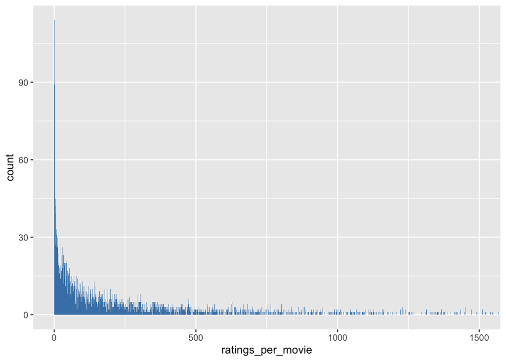

```r
movies_ranking %>% ggplot(aes(ratings_per_movie)) +
  geom_bar(fill = "steelblue", width = 1) + coord_cartesian(c(1,1500))
```

The top ten most popular movies: movies are ranked by the number of reviews/ratings in descending order

```r
small_image_url = "https://liangfgithub.github.io/MovieImages/"
movies_ranking %>%
  top_n(10, ratings_per_movie) %>%
  mutate(Image = paste0('<img src="',
                        small_image_url,
                        MovieID,
                        '.jpg?raw=true"></img>')) %>%
  select('Image', 'Title', 'ratings_per_movie') %>%
  arrange(desc(ratings_per_movie)) %>%
  datatable(class = "nowrap hover row-border",
            escape = FALSE,
            options = list(dom = 't',
                          scrollX = TRUE, autoWidth = TRUE))
```

|  | Image | Title | ratings_per_movie |
| --- | --- | --- | --- |
| 1 |  | American Beauty (1999) | 3428 |
| 2 |  | Star Wars: Episode IV - A New Hope (1977) | 2991 |
| 3 |  | Star Wars: Episode V - The Empire Strikes Back (1980) | 2990 |
| 4 |  | Star Wars: Episode VI - Return of the Jedi (1983) | 2883 |
| 5 |  | Jurassic Park (1993) | 2672 |
| 6 |  | Saving Private Ryan (1998) | 2653 |
| 7 |  | Terminator 2: Judgment Day (1991) | 2649 |
| 8 |  | Matrix, The (1999) | 2590 |
| 9 |  | Back to the Future (1985) | 2583 |
| 10 |  | Silence of the Lambs, The (1991) | 2578 |

The top ten highly-rated (based on their average ratings) among all movies that have received at least 1000 ratings.

```r
#small_image_url = "https://liangfgithub.github.io/MovieImages/"
movies_ranking %>%
  filter(ratings_per_movie > 1000) %>%
  top_n(10, ave_ratings) %>%
  mutate(Image = paste0('<img src="',
                        small_image_url,
                        MovieID,
                        '.jpg?raw=true"></img>')) %>%
  select('Image', 'Title', 'ave_ratings') %>%
  arrange(desc(ave_ratings)) %>%
  datatable(class = "nowrap hover row-border",
            escape = FALSE,
            options = list(dom = 't',
                          scrollX = TRUE, autoWidth = TRUE))
```

|  | Image | Title | ave_ratings |
| --- | --- | --- | --- |
| 1 |  | Shawshank Redemption, The (1994) | 4.555 |
| 2 |  | Godfather, The (1972) | 4.525 |
| 3 |  | Usual Suspects, The (1995) | 4.517 |
| 4 |  | Schindler's List (1993) | 4.51 |
| 5 |  | Raiders of the Lost Ark (1981) | 4.478 |
| 6 |  | Rear Window (1954) | 4.476 |
| 7 |  | Star Wars: Episode IV - A New Hope (1977) | 4.454 |
| 8 |  | Dr. Strangelove or: How I Learned to Stop Worrying and Love the Bomb (1963) | 4.45 |
| 9 |  | Casablanca (1942) | 4.413 |
| 10 |  | Sixth Sense, The (1999) | 4.406 |

```r
genres = as.data.frame(movies$Genres, stringsAsFactors=FALSE)
tmp = as.data.frame(tstrsplit(genres[,1], '[|]',
                              type.convert=TRUE),
                    stringsAsFactors=FALSE)
genre_list = c("Action", "Adventure", "Animation",
               "Children's", "Comedy", "Crime",
               "Documentary", "Drama", "Fantasy",
               "Film-Noir", "Horror", "Musical",
               "Mystery", "Romance", "Sci-Fi",
               "Thriller", "War", "Western")
m = length(genre_list)
genre_matrix = matrix(0, nrow(movies), length(genre_list))
for(i in 1:nrow(tmp)){
  genre_matrix[i,genre_list %in% tmp[i,]]=1
}
colnames(genre_matrix) = genre_list
remove("tmp", "genres")
```

```r
head(genre_matrix)
```

```
##      Action Adventure Animation Children's Comedy Crime Documentary Drama
## [1,]      0         0         1          1      1     0           0     0
## [2,]      0         1         0          1      0     0           0     0
## [3,]      0         0         0          0      1     0           0     0
## [4,]      0         0         0          0      1     0           0     1
## [5,]      0         0         0          0      1     0           0     0
## [6,]      1         0         0          0      0     1           0     0
##      Fantasy Film-Noir Horror Musical Mystery Romance Sci-Fi Thriller War
## [1,]       0         0      0       0       0       0      0        0   0
## [2,]       1         0      0       0       0       0      0        0   0
## [3,]       0         0      0       0       0       1      0        0   0
## [4,]       0         0      0       0       0       0      0        0   0
## [5,]       0         0      0       0       0       0      0        0   0
## [6,]       0         0      0       0       0       0      0        1   0
##      Western
## [1,]       0
## [2,]       0
## [3,]       0
## [4,]       0
## [5,]       0
## [6,]       0
```

```r
movies_ranking = movies_ranking %>% left_join(data.frame(MovieID = movies$MovieID, genre_matrix),
             by = "MovieID")
```

For each genre, check the distribution for number of ratings: documentary movies have least ratings/popularity

```r
genre_list = colnames(movies_ranking)[7:24]
for (i in 1:length(genre_list)) {
        print(genre_list[i])
        print(summary(movies_ranking[movies_ranking[genre_list[i]] == 1,]$ratings_per_movie))
}
```

```
## [1] "Action"
```

```
##    Min. 1st Qu.  Median    Mean 3rd Qu.    Max.
##     1.0   126.0   352.0   520.1   746.0  2991.0
## [1] "Adventure"
##    Min. 1st Qu.  Median    Mean 3rd Qu.    Max.
##     1.0    91.0   276.0   476.7   673.0  2991.0
## [1] "Animation"
##    Min. 1st Qu.  Median    Mean 3rd Qu.    Max.
##     8.0   129.0   305.0   412.3   535.0  2077.0
## [1] "Children.s"
##    Min. 1st Qu.  Median    Mean 3rd Qu.    Max.
##     1.0    65.5   170.0   288.7   355.2  2269.0
## [1] "Comedy"
##    Min. 1st Qu.  Median    Mean 3rd Qu.    Max.
##     1.0    45.0   161.0   306.6   395.5  3428.0
## [1] "Crime"
##    Min. 1st Qu.  Median    Mean 3rd Qu.    Max.
##     1.0    42.0   217.0   395.7   624.0  2513.0
## [1] "Documentary"
##    Min. 1st Qu.  Median    Mean 3rd Qu.    Max.
##    1.00    5.00   28.00   71.91   86.50  798.00
## [1] "Drama"
##    Min. 1st Qu.  Median    Mean 3rd Qu.    Max.
##     1.0    25.0    91.0   237.5   291.0  3428.0
## [1] "Fantasy"
##    Min. 1st Qu.  Median    Mean 3rd Qu.    Max.
##     1.0   154.5   356.0   533.8   711.5  2991.0
## [1] "Film.Noir"
##    Min. 1st Qu.  Median    Mean 3rd Qu.    Max.
##     2.0    32.0   254.0   415.0   520.8  2288.0
## [1] "Horror"
##    Min. 1st Qu.  Median    Mean 3rd Qu.    Max.
##     1.0    36.0   113.0   225.3   263.0  2181.0
## [1] "Musical"
##    Min. 1st Qu.  Median    Mean 3rd Qu.    Max.
##     1.0   112.0   260.0   367.5   525.0  1718.0
## [1] "Mystery"
##    Min. 1st Qu.  Median    Mean 3rd Qu.    Max.
##     1.0   114.8   286.0   386.3   521.5  2288.0
## [1] "Romance"
##    Min. 1st Qu.  Median    Mean 3rd Qu.    Max.
##     1.0    43.5   163.0   321.4   447.0  2883.0
## [1] "Sci.Fi"
##    Min. 1st Qu.  Median    Mean 3rd Qu.    Max.
##     1.0   136.0   378.0   574.1   792.8  2991.0
## [1] "Thriller"
##    Min. 1st Qu.  Median    Mean 3rd Qu.    Max.
##     1.0    79.0   221.0   391.1   540.0  2649.0
## [1] "War"
##    Min. 1st Qu.  Median    Mean 3rd Qu.    Max.
##       1      82     265     486     645    2990
## [1] "Western"
##    Min. 1st Qu.  Median    Mean 3rd Qu.    Max.
##     1.0    46.0   222.0   308.7   397.5  1451.0
```

Recommendation System I:recommendation based on genres

Allowable input of genre is listed below:

```r
genre_list
```

```
##  [1] "Action"      "Adventure"   "Animation"   "Children.s"  "Comedy"
##  [6] "Crime"       "Documentary" "Drama"       "Fantasy"     "Film.Noir"
## [11] "Horror"      "Musical"     "Mystery"     "Romance"     "Sci.Fi"
## [16] "Thriller"    "War"         "Western"
```

```r
user_input_genre = 'Documentary'
```

Recommendation based on popularity: recommend top five most popular movies for the user-input genre. Popularity here refers to the number of ratings/reviews for each movie.

```r
movies_ranking[movies_ranking[user_input_genre] == 1,] %>%
  top_n(5, ratings_per_movie) %>%
  mutate(Image = paste0('<img src="',
                        small_image_url,
                        MovieID,
                        '.jpg?raw=true"></img>')) %>%
  select('Image', 'Title', 'ratings_per_movie') %>%
  arrange(desc(ratings_per_movie)) %>%
  datatable(class = "nowrap hover row-border",
            escape = FALSE,
            options = list(dom = 't',
                          scrollX = TRUE, autoWidth = TRUE))
```

|  | Image | Title | ratings_per_movie |
| --- | --- | --- | --- |
| 1 |  | Roger & Me (1989) | 798 |
| 2 |  | Hoop Dreams (1994) | 716 |
| 3 |  | Crumb (1994) | 491 |
| 4 |  | American Movie (1999) | 295 |
| 5 |  | When We Were Kings (1996) | 277 |

Recommendation of highly-rated movies: recommend top five highly rated movies for the user-input genre. For each genre, filter the movies whose number of ratings is lower than median numbers. It can help to remove movies which have limited ratings but high scores.

```r
threshold = median(movies_ranking[movies_ranking[user_input_genre] == 1,]$ratings_per_movie)
movies_ranking[movies_ranking[user_input_genre] == 1,] %>%
  filter(ratings_per_movie > threshold) %>%
  top_n(5, ave_ratings) %>%
  mutate(Image = paste0('<img src="',
                        small_image_url,
                        MovieID,
                        '.jpg?raw=true"></img>')) %>%
  select('Image', 'Title', 'ave_ratings') %>%
  arrange(desc(ave_ratings)) %>%
  datatable(class = "nowrap hover row-border",
            escape = FALSE,
            options = list(dom = 't',
                          scrollX = TRUE, autoWidth = TRUE))
```

|  | Image | Title | ave_ratings |
| --- | --- | --- | --- |
| 1 |  | When We Were Kings (1996) | 4.321 |
| 2 |  | Decline of Western Civilization, The (1981) | 4.274 |
| 3 |  | Wonderful, Horrible Life of Leni Riefenstahl, The (Die Macht der Bilder) (1993) | 4.258 |
| 4 |  | Thin Blue Line, The (1988) | 4.253 |
| 5 |  | Stop Making Sense (1984) | 4.234 |

Recommendation System II: CF based recommendation

```r
# set.seed(3011)
# train.id = sample(nrow(ratings), floor(nrow(ratings)) * 0.3)
# train = ratings[train.id, ]
# head(train)
#
# test = ratings[-train.id, ]
# head(test)
```

```r
i = paste0('u', ratings$UserID)
j = paste0('m', ratings$MovieID)
x = ratings$Rating
tmp = data.frame(i, j, x, stringsAsFactors = T)
Rmat = sparseMatrix(as.integer(tmp$i), as.integer(tmp$j), x = tmp$x)
rownames(Rmat) = levels(tmp$i)
colnames(Rmat) = levels(tmp$j)
Rmat = new('realRatingMatrix', data = Rmat)
```

```r
range(ratings$MovieID)
```

```
## [1]    1 3952
```

```r
length(unique(ratings$MovieID))
```

```
## [1] 3706
```

```r
range(ratings$UserID)
```

```
## [1]    1 6040
```

```r
length(unique(ratings$UserID))
```

```
## [1] 6040
```

```r
dim(Rmat)
```

```
## [1] 6040 3706
```

Create and evaluate 2 CF based models: 1)User based: for user u and item i, find a set of k users most similiar to u who have also rated item i; use ratings of k users on item i as prediction of user u's ratings on item i 2)Item based: for item i, find other similiar items; estimate item i's ratings based on ratings of similiar items

Similarity metric used: centered cosine similarity for both models Weighted average: prediction is based on weighted average, weighed ratings with normalized similarity weights.

Missing values in the prediction: can be resolved by increasing the number of nearest neighbours, nn paramter for UBCF and k parameter for IBCF

To reduce computation time, sample 1/6 of original data, and compute 10 fold evalutions

```r
Rmat_r = Rmat[1:1000]
```

```r
error_UBCF = matrix(0, nrow=10, ncol=4)
error_IBCF = matrix(0, nrow=10, ncol=4)
for (i in 1:10){
        print(paste0("Folder number: ", i))
        eS = evaluationScheme(Rmat_r, "split", train = 0.8, given = 10)
        rec_UBCF = Recommender(getData(eS, "train"), method = 'UBCF', parameter = list(normalize = 'z-score', method = 'cosine', nn = 50))
        p_UBCF = predict(rec_UBCF, getData(eS, "known"), type = "ratings")
        e_UBCF = calcPredictionAccuracy(p_UBCF, getData(eS, "unknown"))
        #print("Evaluation for UBCF:")
        #print(e_UBCF)
        error_UBCF[i,1] = i
        error_UBCF[i,2:4] = e_UBCF

        rec_IBCF = Recommender(getData(eS, "train"), method = 'IBCF', parameter = list(normalize = 'z-score', method = 'cosine', k = 50))
        p_IBCF = predict(rec_IBCF, getData(eS, "known"), type = "ratings")
        e_IBCF = calcPredictionAccuracy(p_IBCF, getData(eS, "unknown"))
        #print("Evaluation for IBCF")
        #print(e_IBCF)
        error_IBCF[i,1] = i
        error_IBCF[i,2:4] = e_IBCF

}
```

```
## [1] "Folder number: 1"
## [1] "Folder number: 2"
## [1] "Folder number: 3"
## [1] "Folder number: 4"
## [1] "Folder number: 5"
## [1] "Folder number: 6"
## [1] "Folder number: 7"
## [1] "Folder number: 8"
## [1] "Folder number: 9"
## [1] "Folder number: 10"
```

```r
error_UBCF = data.frame(error_UBCF)
colnames(error_UBCF) = c("Fold", "RMSE", "MSE", "MAE")

error_IBCF = data.frame(error_IBCF)
colnames(error_IBCF) = c("Fold", "RMSE", "MSE", "MAE")
```

```r
error_UBCF
```

```
##    Fold     RMSE      MSE       MAE
## 1     1 1.125597 1.266969 0.8689262
## 2     2 1.122196 1.259324 0.8728255
## 3     3 1.155466 1.335102 0.8991008
## 4     4 1.147277 1.316245 0.8952571
## 5     5 1.200354 1.440849 0.9313133
## 6     6 1.164222 1.355412 0.9023894
## 7     7 1.151890 1.326851 0.8993737
## 8     8 1.119371 1.252992 0.8698562
## 9     9 1.133753 1.285395 0.8745768
## 10   10 1.142628 1.305598 0.8859071
```

```r
error_IBCF
```

```
##    Fold     RMSE      MSE      MAE
## 1     1 1.470771 2.163168 1.139785
## 2     2 1.404662 1.973076 1.028066
## 3     3 1.483539 2.200887 1.134379
## 4     4 1.386889 1.923462 1.066229
## 5     5 1.742217 3.035322 1.298973
## 6     6 1.357302 1.842269 1.023138
## 7     7 1.446242 2.091617 1.075792
## 8     8 1.400764 1.962141 1.065378
## 9     9 1.697372 2.881072 1.276895
## 10   10 1.601888 2.566044 1.186211
```